# OpenPowerLiftingEDA

Filip Głogowski

2023-11-26

Pakiety, z których będę korzystać:

```r
library(dplyr)
library(ggplot2)
library(mice)
library(tidyverse)
library(corrplot)
```

# Wstęp

Zacznijmy od przedstawienia zestawu danych, z którego bedziemy korzystać. Są to dane ze strony https://openpowerlifting.gitlab.io/opl-csv/ i przedstawiają dane dotyczące występów zawodników od początku istnienia organizacji do obecnego roku.

```r
head(openpowerlifting2023)
```

```
##                     Name Sex Event Equipment  Age AgeClass BirthYearClass
## 1            Alona Vladi   F   SBD       Raw 33.0    24-34          24-39
## 2     Galina Solovyanova   F   SBD       Raw 43.0    40-44          40-49
## 3         Daniil Voronin   M   SBD       Raw 15.5    16-17          14-18
## 4         Aleksey Krasov   M   SBD       Raw 35.0    35-39          24-39
## 5 Margarita Pleschenkova   M   SBD       Raw 26.5    24-34          24-39
## 6      Sergey Timoshenko   M   SBD       Raw 15.5    16-17          14-18
##   Division BodyweightKg WeightClassKg Squat1Kg Squat2Kg Squat3Kg Squat4Kg
## 1        O        58.30            60       75       80    -90.0       NA
## 2       M1        73.10            75       95      100    105.0       NA
## 3        T        67.40            75       85       90    100.0       NA
## 4        O        66.65            75      125      132    137.5       NA
## 5        O        72.45            75       80       85     90.0       NA
## 6        T        78.80            85       90      -95    100.0       NA
##   Best3SquatKg Bench1Kg Bench2Kg Bench3Kg Bench4Kg Best3BenchKg Deadlift1Kg
```

[output cut: 27 more lines]

```r
summary(openpowerlifting2023)
```

```
##      Name               Sex               Event            Equipment
##  Length:3043830     Length:3043830     Length:3043830     Length:3043830
##  Class :character   Class :character   Class :character   Class :character
##  Mode  :character   Mode  :character   Mode  :character   Mode  :character
##
##
##
##
##       Age            AgeClass         BirthYearClass       Division
##  Min.   : 0.0      Length:3043830     Length:3043830     Length:3043830
##  1st Qu.:20.5      Class :character   Class :character   Class :character
##  Median :27.5      Mode  :character   Mode  :character   Mode  :character
##  Mean   :30.8
##  3rd Qu.:38.5
##  Max.   :98.0
##  NA's   :1070441
##   BodyweightKg    WeightClassKg         Squat1Kg          Squat2Kg
##  Min.   : 10.00   Length:3043830     Min.   :-555.0    Min.   :-580.0
##  1st Qu.: 67.20   Class :character   1st Qu.:  90.0    1st Qu.:  80.0
##  Median : 81.95   Mode  :character   Median : 145.0    Median : 145.5
##  Mean   : 84.17                      Mean   : 115.3    Mean   :  99.5
##  3rd Qu.: 98.79                      3rd Qu.: 197.5    3rd Qu.: 202.5
##  Max.   :300.00                      Max.   : 555.0    Max.   : 577.5
##  NA's   :38370                       NA's   :2138072   NA's   :2147310
##     Squat3Kg          Squat4Kg        Best3SquatKg        Bench1Kg
##  Min.   :-600.5    Min.   :-550.0    Min.   :-508.0    Min.   :-635.5
##  1st Qu.:-150.0    1st Qu.: -80.0    1st Qu.: 122.5    1st Qu.:  57.5
##  Median : 117.5    Median : 130.0    Median : 170.0    Median : 102.5
##  Mean   :  41.0    Mean   :  76.9    Mean   : 174.4    Mean   :  83.6
##  3rd Qu.: 192.5    3rd Qu.: 195.0    3rd Qu.: 217.7    3rd Qu.: 140.0
##  Max.   : 595.0    Max.   : 592.4    Max.   : 595.0    Max.   : 551.0
##  NA's   :2171231   NA's   :3035377   NA's   :1009254   NA's   :1653006
##     Bench2Kg          Bench3Kg          Bench4Kg        Best3BenchKg
##  Min.   :-635.5    Min.   :-575.0    Min.   :-515.0    Min.   :-522.5
##  1st Qu.: -27.5    1st Qu.:-132.5    1st Qu.:-120.0    1st Qu.:  75.0
##  Median :  95.0    Median : -57.5    Median :  75.0    Median : 115.0
##  Mean   :  57.6    Mean   : -14.7    Mean   :  24.3    Mean   : 118.1
##  3rd Qu.: 140.0    3rd Qu.: 117.5    3rd Qu.: 150.0    3rd Qu.: 151.9
##  Max.   : 521.6    Max.   : 635.5    Max.   : 487.6    Max.   : 635.5
##  NA's   :1668628   NA's   :1711062   NA's   :3022840   NA's   :358592
```

[output cut: 33 more lines]

```
##  Length:3043830     Length:3043830     Length:3043830     Length:3043830
##  Class :character   Class :character   Class :character   Class :character
##  Mode  :character   Mode  :character   Mode  :character   Mode  :character
##
##
##
##
##    MeetName
##  Length:3043830
##  Class :character
##  Mode  :character
##
##
##
##
```

Przedstawiam nazwy kolum wraz z ich wytłumaczeniem:

1. **Imię i Nazwisko (`Name`):**
   - Obowiązkowe. Zawiera imię i nazwisko zawodnika w kodowaniu UTF-8.
   - W przypadku wspólnego imienia i nazwiska dwóch zawodników, odróżniane są za pomocą symbolu # i unikalnej liczby. Na przykład, dwóch zawodników o nazwisku Jan Kowalski otrzymałoby wartości Jan Kowalski #1 i Jan Kowalski #2.
2. **Płeć (`Sex`):**
   - Obowiązkowe. Określa płeć zawodnika, przyjmując wartości M (mężczyzna), F (kobieta) lub Mx (płeć neutralna).
   - Kategoria Mx jest neutralna płciowo i jest szczególnie odpowiednia dla zawodników niebinarnych.
3. **Typ Zawodów (`Event`):**
   - Obowiązkowe. Określa rodzaj zawodów, w jakich zawodnik uczestniczył.
   - Wartości to: SBD (Trójbojowy), BD (Bench-Deadlift), SD (Squat-Deadlift), SB (Squat-Bench), S (Tylko przysiady), B (Tylko bench press), D (Tylko martwy ciąg).
4. **Sprzęt (`Equipment`):**
   - Obowiązkowe. Określa kategorię sprzętu, na którym przeprowadzane były próby.
   - Przykładowe wartości: Raw (Bez dodatkowego sprzętu), Wraps (Dozwolone bandażowanie kolan), Single-ply (Wyposażenie jednowarstwowe), Multi-ply (Wyposażenie wielowarstwowe), Unlimited (Wyposażenie wielowarstwowe lub sprzęt z gumy), Straps (Dozwolone użycie pasów podczas martwego ciągu).
5. **Wiek (`Age`):**
   - Opcjonalne. Wiek zawodnika na dzień rozpoczęcia zawodów, jeśli dostępny.
   - Wiek może być podany jako dokładny lub przybliżony (z dodatkowym 0.5), co oznacza, że zawodnik może mieć dwa możliwe wieki (n lub n+1).
6. **Klasa Wiekowa (`AgeClass`):**
   - Opcjonalne. Klasa wiekowa, do której należy zawodnik, na przykład 40-45. Bazuje na dokładnym wieku zawodnika w dniu zawodów.
7. **Klasa Roku Urodzenia (`BirthYearClass`):**
   - Opcjonalne. Klasa roku urodzenia, np. 40-49. Zakres obejmuje najstarszy wiek zawodnika w danym roku. Wykorzystywane głównie przez federacje IPF i ich afiliacje.
8. **Dywizja (`Division`):**
   - Opcjonalne. Dowolny tekst w kodowaniu UTF-8 opisujący dywizję zawodów, np. Open lub Juniors 20-23.
9. **Masa Ciała (`BodyweightKg`):**
   - Opcjonalne. Zarejestrowana masa ciała zawodnika w chwili zawodów, z dokładnością do dwóch miejsc po przecinku.
10. **Klasa Masy Ciała (`WeightClassKg`):**
    - Opcjonalne. Klasa masy ciała, w której zawodnik uczestniczył, z dokładnością do dwóch miejsc po przecinku. Może być podana jako maksimum lub minimum.
11. **Próby Przysiadu (`Squat1Kg`, `Squat2Kg`, `Squat3Kg`, `Squat4Kg`):**
    - Opcjonalne. Wartości pierwszych, drugich, trzecich i ewentualnie czwartych prób dla przysiadu.
12. **Próby Ławki (`Bench1Kg`, `Bench2Kg`, `Bench3Kg`, `Bench4Kg`):**
    - Opcjonalne. Wartości pierwszych, drugich, trzecich i ewentualnie czwartych prób dla ławki.
13. **Próby Martwego Ciągu (`Deadlift1Kg`, `Deadlift2Kg`, `Deadlift3Kg`, `Deadlift4Kg`):**
    - Opcjonalne. Wartości pierwszych, drugich, trzecich i ewentualnie czwartych prób dla martwego ciągu.
14. **Najlepsze Wyniki (`Best3SquatKg`, `Best3BenchKg`, `Best3DeadliftKg`):**
    - Opcjonalne. Maksymalne wartości spośród pierwszych trzech udanych prób dla każdej z trzech konkurencji.
15. **Łączna Masa Podniesiona (`TotalKg`):**
    - Opcjonalne. Suma wartości **`Best3SquatKg`**, **`Best3BenchKg`** i **`Best3DeadliftKg`**, jeśli wszystkie trzy próby były udane. Jeśli jedna z prób nie powiodła się lub zawodnik został zdyskwalifikowany z innych powodów, pole **`TotalKg`** jest puste.
16. **Punkty Dots:**
    - Opcjonalne. Liczba dodatnia, jeśli można obliczyć punkty Dots, puste, jeśli zawodnik został zdyskwalifikowany.
17. **Punkty Wilks:**
    - Opcjonalne. Liczba dodatnia, jeśli można obliczyć punkty Wilks, puste, jeśli zawodnik został zdyskwalifikowany.
18. **Punkty Glossbrenner:**
    - Opcjonalne. Liczba dodatnia, jeśli można obliczyć punkty Glossbrenner, puste, jeśli zawodnik został zdyskwalifikowany.
19. **Punkty Goodlift:**
    - Opcjonalne. Punkty IPF GL (Successor to IPF Points). Liczba dodatnia, jeśli można obliczyć punkty IPF GL, puste, jeśli zawodnik został zdyskwalifikowany lub punkty IPF GL były niezdefiniowane dla danego typu zawodów.
20. **Testowane (`Tested`):**
    - Opcjonalne. **`Yes`**, jeśli zawodnik startował w kategorii testowanej pod kątem stosowania substancji dopingujących, puste w przeciwnym razie.
21. **Kraj (`Country`):**
    - Opcjonalne. Kraj pochodzenia zawodnika, jeśli jest znany.
22. **Stan (`State`):**
    - Opcjonalne. Stan, prowincja lub region pochodzenia zawodnika, jeśli jest znany.
23. **Federacja (`Federation`):**
    - Obowiązkowe. Federacja, która zorganizowała zawody.
24. **Nadrzędna Federacja (`ParentFederation`):**
    - Opcjonalne. Nadrzędna federacja, która przyznała sankcję zawodom, zazwyczaj międzynarodowa.
25. **Data (`Date`):**
    - Obowiązkowe. Data rozpoczęcia zawodów w formacie ISO 8601.
26. **Kraj Zawodów (`MeetCountry`):**
    - Obowiązkowe. Kraj, w którym odbyły się zawody.
27. **Stan Zawodów (`MeetState`):**
    - Opcjonalne. Stan, prowincja lub region, w którym odbyły się zawody.
28. **Nazwa Zawodów (`MeetName`):**
    - Obowiązkowe. Nazwa zawodów, bez uwzględniania roku i federacji.

# Przygotowanie danych do pracy.

Filtrowanie Wierszy Związanych z Trójbojem Siłowym:

Wybieram tylko te wiersze z openpowerlifting2023, które są związane z trójbojem siłowym (Event == ‘SBD’) tworząc z nich nową ramkę danych SBD zawierającą tylko wybrane kolumny z wcześniej utworzonej ramki danych openpowerlifting2023. Usuwam brakujące dane za pomocą funkcji `na.omit()`, która usuwa wiersze zawierające puste dane `NA`.

Usuwwam też wiersze, które nie maja sklasyfikowanego przedziału wiekowego i wiersze, w których wiek jest mniejszy od 10 ze względu na to, że starsze dane mogły zawierać osoby, których wiek nie był znany w takich przypadkach wpisywano czasem zaniżony wiek.

Zmieniamwartości w kolumnie `Tested`. Jeżeli kolumna jest pusta, ustawiam “Brak Testu”, a jeżeli jest równa “Yes”, ustawiam “Testowany”.

Zaokrąglam w dól wartości wieku w kolumnie `Age` wynika to z tego, że jeśli data urodzenia zawodnika nie była doprecyzowana wpisywano wartość z połówką np.14,5. Oznaczało to, że zawodnik może mieć zarówno 14 jak i 15 lat.

Tworzę też ramkę danych `SBDName`, która jest pogrupowaną ramką `SBD` według zawodników wybierając wiersz w którym ten zawodnik osiągnał najlepszy wynik.

```r
SBD <- filter(openpowerlifting2023,Event=='SBD')
SBD <- subset(SBD, select = c("Name", "Sex", "Event", "Equipment", "Age", "AgeClass", "Division",
                              "BodyweightKg", "WeightClassKg", "Best3SquatKg", "Best3BenchKg",
                              "Best3DeadliftKg", "TotalKg", "Place", "Date", "Tested", "MeetName","Country"))

SBD<- na.omit(SBD)
SBD <- SBD[!(SBD$AgeClass==""),]
SBD<-SBD[SBD$Age>=10,]
SBD <- SBD %>%
  mutate(Tested = ifelse(Tested == "", "Brak Testu",
                         ifelse(Tested == "Yes", "Testowany", Tested)))
SBD <- SBD %>%
  mutate(Age = floor(Age))

SBDName <- SBD %>%
  group_by(Name) %>%
  slice_max(order_by = TotalKg) %>%
  ungroup() %>%
  distinct(Name, .keep_all = TRUE)
```

# W jakim wieku zawodnicy osiągali najlepsze wyniki?

Zaczniemy od przedstawienia przeglądnięcia wykresów gęstości.

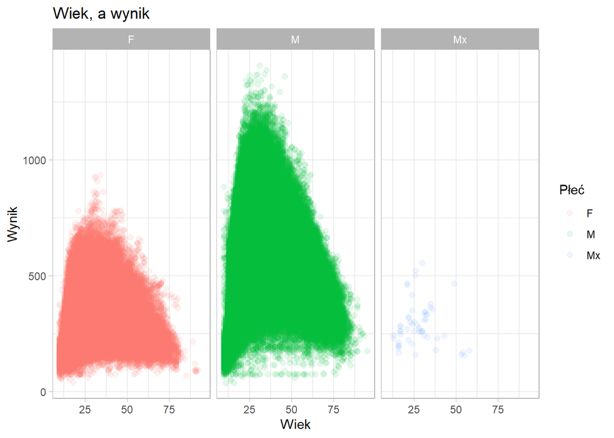

```r
SBD %>%
  ggplot() +
  theme_light()+
  geom_point(aes(x=Age,y= TotalKg, color = Sex), alpha = 0.1,size=2)+
  facet_wrap(~ Sex, ncol = 3) +
  labs(title="Wiek, a wynik",
       x="Wiek",
       y="Wynik",
       color="Płeć")
```

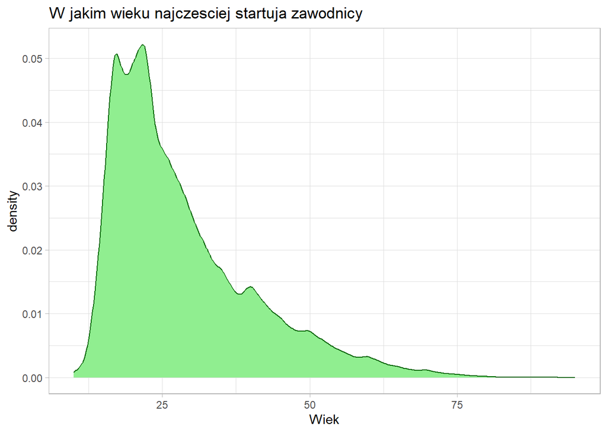

```r
SBD%>%
  ggplot() +
  geom_density(aes(x = Age),
               color = "darkgreen", fill = "lightgreen") +
  theme_light() +
  labs(title = "W jakim wieku najczesciej startuja zawodnicy",
       x = "Wiek")
```

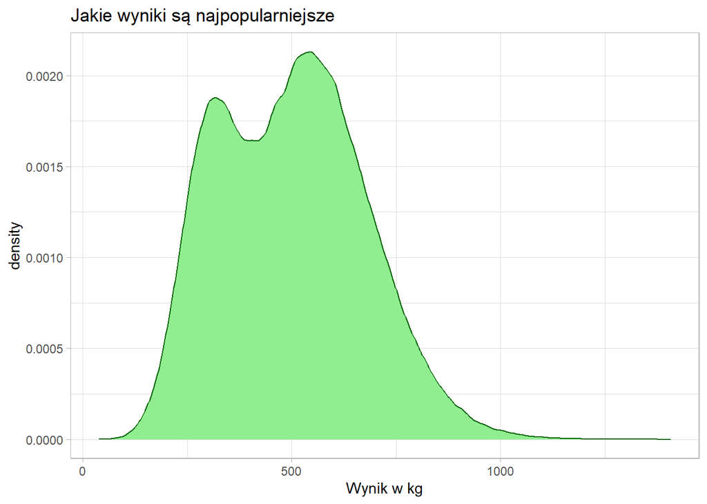

```r
SBD %>%
  ggplot() +
  geom_density(aes(x = TotalKg),
               color = "darkgreen", fill = "lightgreen") +
  theme_light() +
  labs(title = "Jakie wyniki są najpopularniejsze",
       x = "Wynik w kg")
```

```r
sredniWynikWiek <- SBDName %>%
  group_by(Age) %>%
  summarise(SredniWynik = mean(TotalKg, na.rm = TRUE))
sredniWynikWiek[which.max(sredniWynikWiek$SredniWynik),]
```

```
## # A tibble: 1 × 2
##     Age SredniWynik
##   <dbl>       <dbl>
## 1    29        526.
```

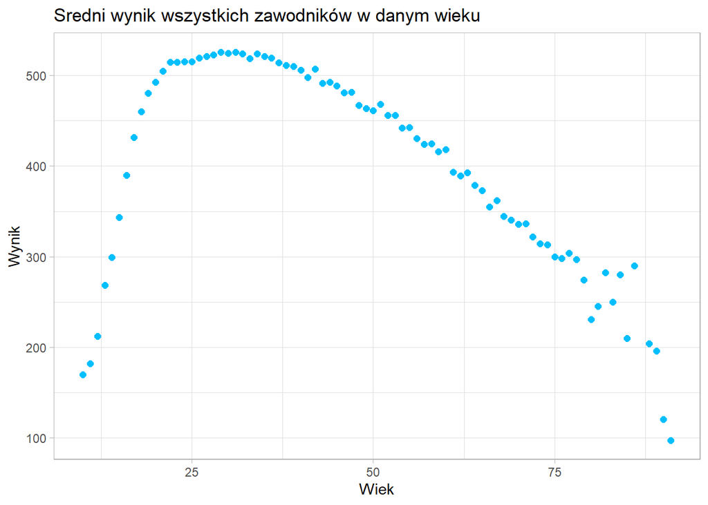

```r
sredniWynikWiek %>%
  ggplot() +
  theme_light()+
  geom_point(aes(x=Age,y= SredniWynik),color="deepskyblue",size=2)+
  labs(title="Sredni wynik wszystkich zawodników w danym wieku",
       x="Wiek",
       y="Wynik",)
```

# Czy nietestowani zawodnicy osiągają lepsze wyniki?

Zacznijmy od sprawdzenia czy więcej jest zawodników testowanych czy nie testowanych (używających doping)

```r
table(SBD$Tested)
```

```
##
## Brak Testu  Testowany
##     298482     849593
```

Jak widać przeważają zawodnicy testowani, wynika to z tego, że wiekszość zawodów jest właśnie dla osób nie używających dopingu.

Teraz przeanalizujemy najlepsze wyniki sportowców. Stworzę dwie ramki danych, jedna `sredniWynikWiekD`, która zawiera najlepsze wyniki osób używających doping oraz `sredniWynikWiekBD,` która zawiera najlepsze wyniki osób nie używających dopingu. Następnie wypisuje w jakim wieku najlepszy wynik osiągają osoby testowane i nie testowane.

```r
sredniWynikWiekD <- SBDName %>%
  group_by(Age) %>%
  summarise(SredniWynik = mean(TotalKg[Tested=="Brak Testu"], na.rm = TRUE))%>%
  na.omit(sredniWynikWiekBD)

sredniWynikWiekBD <- SBDName %>%
  group_by(Age) %>%
  summarise(SredniWynik = mean(TotalKg[Tested=="Testowany"], na.rm = TRUE))%>%
  na.omit(sredniWynikWiekBD)

sredniWynikWiekBD[which.max(sredniWynikWiekBD$SredniWynik),]
```

```
## # A tibble: 1 × 2
##     Age SredniWynik
##   <dbl>       <dbl>
## 1    22        512.
```

```r
sredniWynikWiekD[which.max(sredniWynikWiekD$SredniWynik),]
```

```
## # A tibble: 1 × 2
##     Age SredniWynik
##   <dbl>       <dbl>
## 1    34        560.
```

Jak widać zawodnicy naturalni, nie biorący dopingu osiągali srednio najlepsze wyniki w wieku 22 lat a zawodnicy biorący doping w wieku 34 lat.

Narysujemy teraz wykres pokazujący jak rozkładały się wyniki z podziałem na osoby testowane i nie testowane.

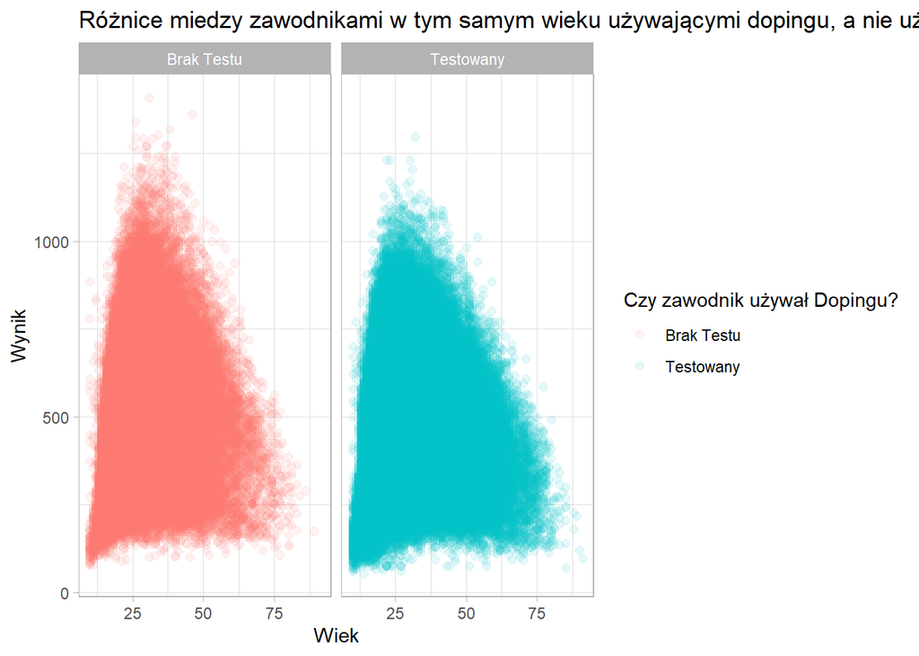

```r
SBDName %>%
  ggplot() +
  theme_light()+
  geom_point(aes(x=Age,y= TotalKg, color = Tested), alpha = 0.1,size=2)+
  facet_wrap(~ Tested) +
  labs(title="Różnice miedzy zawodnikami w tym samym wieku używającymi dopingu, a nie używającymi",
       x="Wiek",
       y="Wynik",
       color="Czy zawodnik używał Dopingu?")
```

Przedstawię teraz wykres średnich wyników w każdym wieku, aby lepiej zobrazować, różnice między zawodnikami testowanymi, a nie testowanymi.

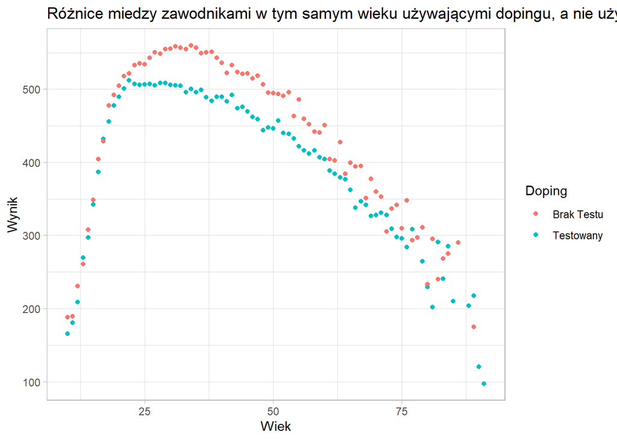

```r
polaczonewynikiWW <- bind_rows(list(Testowany = sredniWynikWiekBD, 'Brak Testu' = sredniWynikWiekD), .id = 'Doping')
polaczonewynikiWW %>%
  ggplot()+
  theme_light()+
  geom_point(aes(x=Age, y=SredniWynik,color=Doping))+

  labs(title="Różnice miedzy zawodnikami w tym samym wieku używającymi dopingu, a nie używającymi",
       x="Wiek",
       y="Wynik",)
```

Jak widać zawodnicy nie testowani zdobywali znacznie lepsze wyniki po 22 roku życia od zawodników testowanych.

# Przy użyciu jakiego sprzętu wyniki są najlepsze?

Zacznę od zapoznania się z wykresem pokazującym jak rozkładają się wyniki przy używaniu różnych sprzętów.

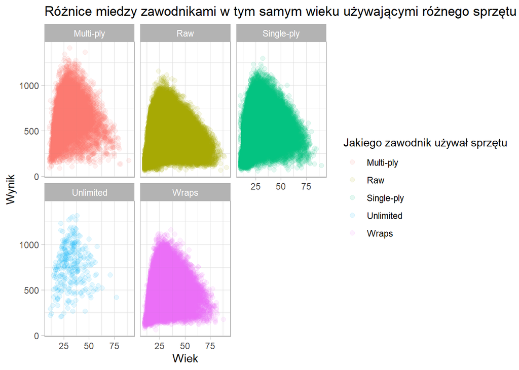

```r
SBDName %>%
  ggplot() +
  theme_light()+
  geom_point(aes(x=Age,y= TotalKg, color = Equipment), alpha = 0.1,size=2)+
  facet_wrap(~ Equipment) +
  labs(title="Różnice miedzy zawodnikami w tym samym wieku używającymi różnego sprzętu",
       x="Wiek",
       y="Wynik",
       color="Jakiego zawodnik używał sprzętu")
```

Zajmę się teraz porządkowaniem danych tak aby znaleźć średnią wyniku dla każdego wieku i sprzętu. Tak aby wyniki były czytelniejsze i łatwiej można było wyciągać wnioski.

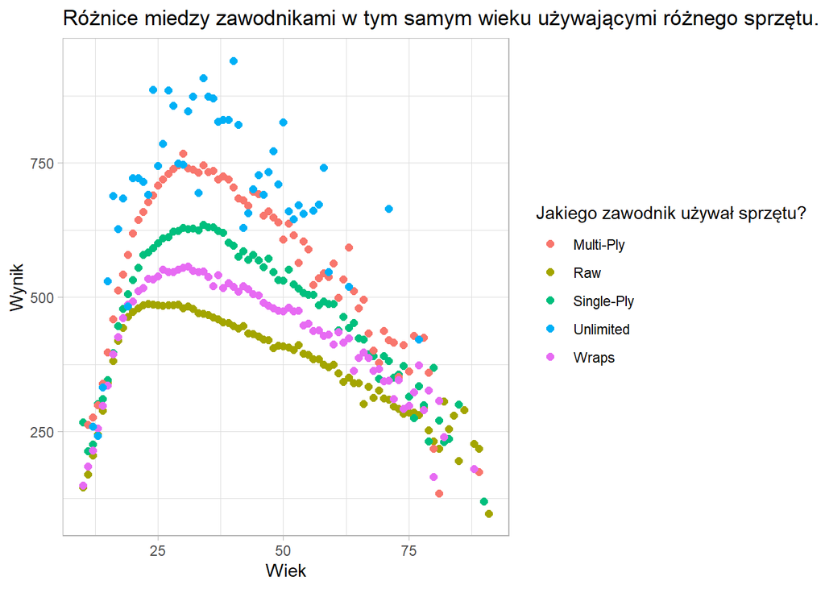

```r
sredniWynikWiekRAW <- SBDName %>%
  group_by(Age) %>%
  summarise(SredniWynik = mean(TotalKg[Equipment=="Raw"], na.rm = TRUE))%>%
  na.omit(sredniWynikWiekBD)

sredniWynikWiekSP <- SBDName %>%
  group_by(Age) %>%
  summarise(SredniWynik = mean(TotalKg[Equipment=="Single-ply"], na.rm = TRUE))%>%
  na.omit(sredniWynikWiekBD)

sredniWynikWiekMP <- SBDName %>%
  group_by(Age) %>%
  summarise(SredniWynik = mean(TotalKg[Equipment=="Multi-ply"], na.rm = TRUE))%>%
  na.omit(sredniWynikWiekBD)

sredniWynikWiekWR<- SBDName %>%
  group_by(Age) %>%
  summarise(SredniWynik = mean(TotalKg[Equipment=="Wraps"], na.rm = TRUE))%>%
  na.omit(sredniWynikWiekBD)

sredniWynikWiekUN <- SBDName %>%
  group_by(Age) %>%
  summarise(SredniWynik = mean(TotalKg[Equipment=="Unlimited"], na.rm = TRUE))%>%
  na.omit(sredniWynikWiekBD)


polaczonewynikiEQ <- bind_rows(list(Raw = sredniWynikWiekRAW,  'Single-Ply' = sredniWynikWiekSP, 'Multi-Ply'=sredniWynikWiekMP,Wraps=sredniWynikWiekWR,
Unlimited=sredniWynikWiekUN), .id = 'Sprzęt')

polaczonewynikiEQ %>%
  ggplot() +
  theme_light()+
  geom_point(aes(x=Age,y= SredniWynik, color = Sprzęt),size=2)+
  labs(title="Różnice miedzy zawodnikami w tym samym wieku używającymi różnego sprzętu.",
       x="Wiek",
       y="Wynik",
       color="Jakiego zawodnik używał sprzętu?")
```

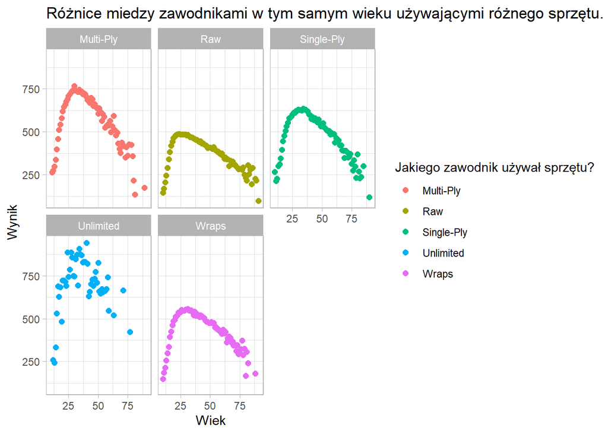

```r
polaczonewynikiEQ %>%
  ggplot() +
  theme_light()+
  geom_point(aes(x=Age,y= SredniWynik, color = Sprzęt),size=2)+
  facet_wrap(~Sprzęt)+
  labs(title="Różnice miedzy zawodnikami w tym samym wieku używającymi różnego sprzętu.",
       x="Wiek",
       y="Wynik",
       color="Jakiego zawodnik używał sprzętu?")
```

Z tych wykresów dokładnie widać, że wraz z wzrastającą ilością sprzętu zwiekszają się wyniki. Dlatego im mniej sprzętu tym bardziej prestiżowe rekordy siłowe.

# Waga zawodnika, a wynik.

Zajmę się teraz badaniem jak duży wpływ na wynik zawodnika ma jego waga. Czy istnieje więc powód istnienia kategorii wagowych?

Zacznę najpierw od narysowania wykresu, który pokaże wyniki dla danej wagi.

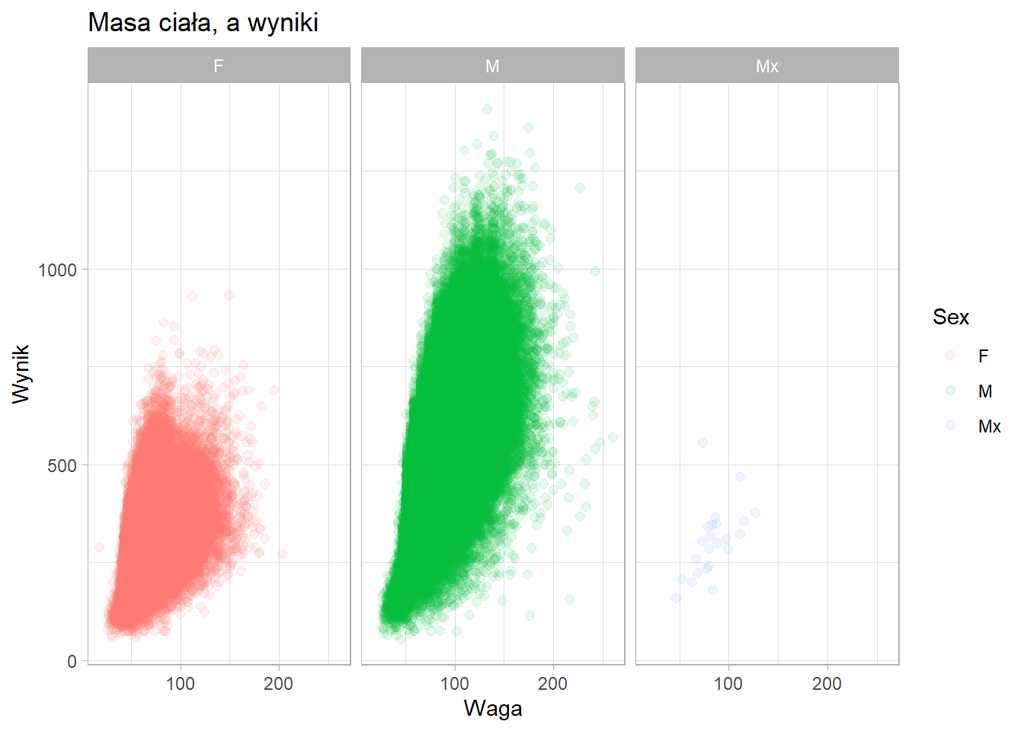

```r
SBDName %>%
  ggplot()+
  theme_light()+
  geom_point(aes(x=BodyweightKg,y= TotalKg, color = Sex), alpha = 0.1,size=2)+
  facet_wrap(~Sex) +
  labs(title="Masa ciała, a wyniki",
       x="Waga",
       y="Wynik",)
```

Jak można zauważyć, w miarę zwiekszającej się wagi zwiekszają sie też wyniki zbadajmy ten problem jeszcze przy użyciu korelacji rangowej Spearmana

```r
cor(SBDName$BodyweightKg,SBDName$TotalKg,method='spearman')
```

```
## [1] 0.6968636
```

Jak widać współczynnik korelacji rangowej Spearmana wynosi około 0,7 co wskazuje na dość silną zależność. Nie bez powodu zawodnicy startują w różnych kategoriach wagowych, każdy kilogram może mieć znaczenie w trójboju siłowym.

# Zawodnicy tej samej wagi natomiast innej płci.

W tym podpunkcie skupiam się na dwóch płciach. Niestety brakuje wystarczającej liczby danych dotyczących osób niebinarnych, aby wyciągać wnioski o ich wynikach.

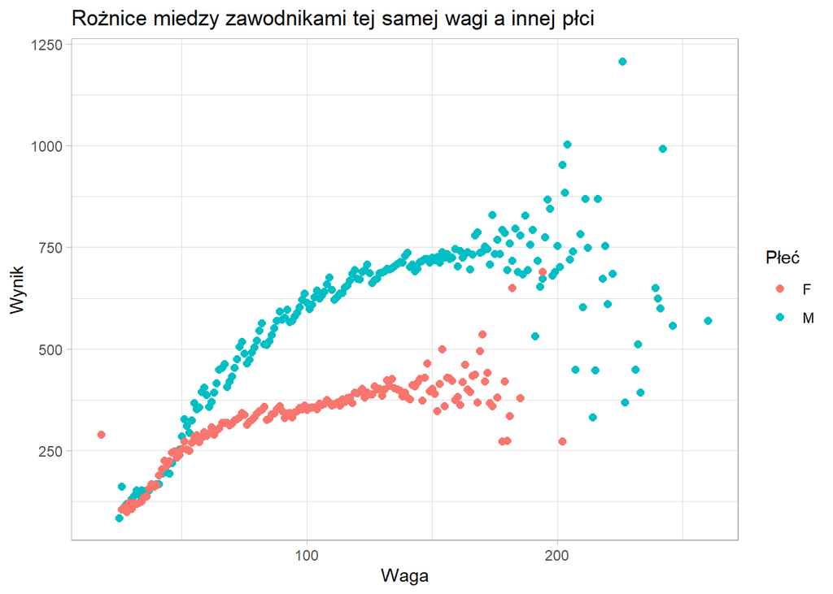

```r
SBDF<- filter(SBDName, Sex == "F")
SBDM<- filter(SBDName, Sex == "M")

sredniwynikWagaM <- SBDM %>%
  group_by(BodyweightKg) %>%
  mutate(BodyweightKg = floor(BodyweightKg))%>%
  summarise(SredniWynik = mean(TotalKg, na.rm = TRUE))
sredniwynikWagaF <- SBDF %>%
  group_by(BodyweightKg) %>%
  mutate(BodyweightKg = floor(BodyweightKg))%>%
  summarise(SredniWynik = mean(TotalKg, na.rm = TRUE))

wynikiWagaPlec <- bind_rows(list(M = sredniwynikWagaM, F = sredniwynikWagaF), .id = 'Plec')
wynikiWagaPlec %>%
  ggplot() +
  theme_light()+
  geom_point(aes(x=BodyweightKg,y= SredniWynik, color = Plec),size=2)+
  labs(title="Rożnice miedzy zawodnikami tej samej wagi a innej płci",
       x="Waga",
       y="Wynik",
       color="Płeć")
```

Widać, że im wieksza waga tym wieksza różnica pomiędzy wynikami, aż dochodzimy do ok. 200 kg wtedy wyniki stają się mniej przewidywalne ze względu na mniejsza ilość zawodników w takiej wadze. Natomiast im niższa waga tym bardziej płeć przestaje mieć znaczenie.

# Które podejście średnio wychodziło najlepiej?

Zacznę od stworzenia nowej ramki danych `Podejscia`, która zawiera kolumny z informacjami dotyczącymi trzech podejść z każdego ćwiczenia

```r
Podejscia <- filter(openpowerlifting2023,Event=='SBD')
Podejscia <- subset(Podejscia, select = c("Name","Squat1Kg","Squat2Kg","Squat3Kg",
                                          "Bench1Kg","Bench2Kg","Bench3Kg",
                                          "Deadlift1Kg","Deadlift2Kg","Deadlift3Kg"                                           ,"TotalKg"))%>%
            na.omit(Podejscia)
```

Teraz zajmę się rysowaniem wykresu. Wykres bedzie przedstawiał średnie każdego ćwiczenia i podejścia. Dlatego stworzę nową ramkę danych, która bedzię zawierać tylko numeryczne dane, aby policzyć dla nich średnią.

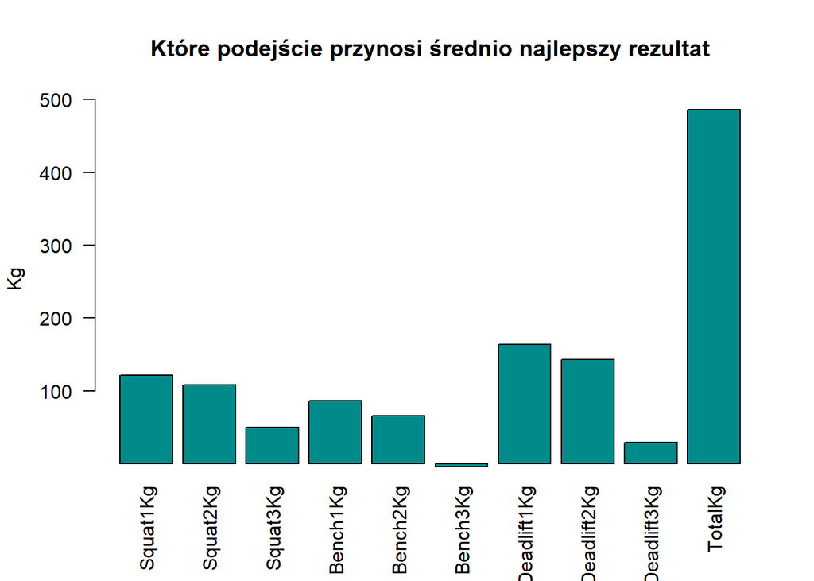

```r
Numeryczne3podejscia <- Podejscia[, sapply(Podejscia, is.numeric)]

SrednieZ3podejsc <- colMeans(Numeryczne3podejscia, na.rm = TRUE)



barplot(SrednieZ3podejsc,
        main = "Które podejście przynosi średnio najlepszy rezultat",
        col = "darkcyan",
        names.arg = names(SrednieZ3podejsc),
        ylim = c(2, max(SrednieZ3podejsc) + 20),
        ylab = "Kg",
        las=2)
```

Jak widać na wykresie, średnio najlepiej wychodziło pierwsze podejście. Może wynikać to z tego, że zawdonicy chcąc poprawić swój wynik próbowali podnieść większy cieżar przez co nie udawało im się i wpisywano wtedy wagę, którą zawodnik probował podnieść na minusie co oznacza nie udaną próbę.

# Czy siła przekłada się pomiedzy różnymi ćwiczeniami?

W tym podpunkcie zajmę się sprawdzeniem czy siła z jednego ćwiczenia przekłada sie na drugie ćwiczenie. W tym celu wykorzystam korelacje rang spearmana oraz narysuję wykres korelacji w celu lepszej wyizualizacji danych.

```r
PodejsciaNajlepsze <- filter(openpowerlifting2023,Event=='SBD')
PodejsciaNajlepsze <- subset(PodejsciaNajlepsze, select = c("Best3SquatKg","Best3BenchKg","Best3DeadliftKg"))%>%
  na.omit(PodejsciaNajlepsze)
summary(PodejsciaNajlepsze)
```

```
##   Best3SquatKg     Best3BenchKg     Best3DeadliftKg
##  Min.   :-445.0   Min.   :-362.50   Min.   :-370.0
##  1st Qu.: 124.7   1st Qu.:  70.31   1st Qu.: 140.6
##  Median : 170.0   Median : 107.50   Median : 188.2
##  Mean   : 174.8   Mean   : 110.62   Mean   : 189.4
##  3rd Qu.: 217.7   3rd Qu.: 142.50   3rd Qu.: 235.0
##  Max.   : 595.0   Max.   : 544.31   Max.   : 487.5
```

```r
Kor = cor(PodejsciaNajlepsze,
          method = "spearman")
round(Kor, 2)
```

```
##                 Best3SquatKg Best3BenchKg Best3DeadliftKg
## Best3SquatKg            1.00         0.91            0.92
## Best3BenchKg            0.91         1.00            0.90
## Best3DeadliftKg         0.92         0.90            1.00
```

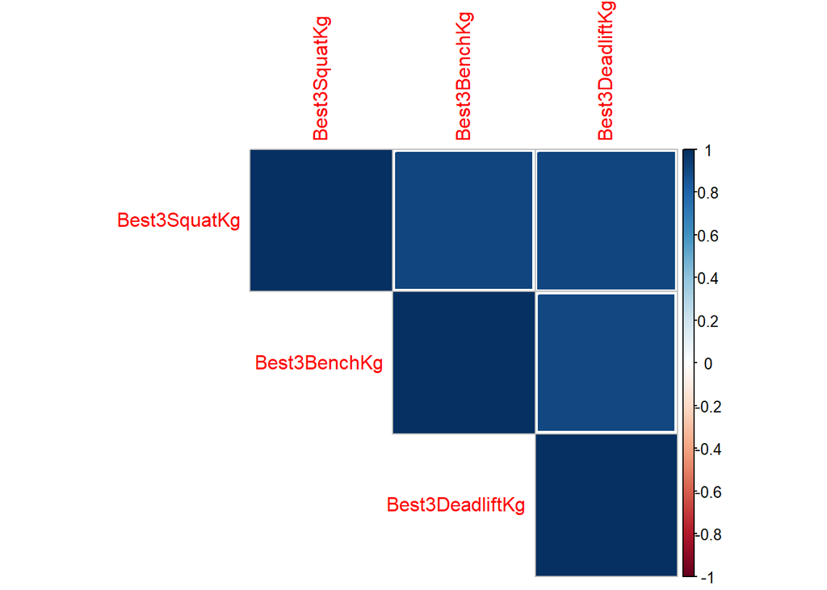

```r
corrplot(Kor, method = "square", type = "upper")
```

Jak widać współczynnik korelacji jest bardzo wysoki co oznacza dużą zależność. Wynik nie jest niczym nie spodziewanym, zawodnicy w końcu przygotowują się do każdego ćwiczenia. Jednakże ciekawa jest obserwacja tak dużych wyników korelacji. Dowodzi to temu, że zawodnicy nie mają ulubionego ćwiczenia i wraz ze wzrostem wyników jednego ćwiczenia wzrastają też wyniki w innych ćwiczeniach.

# Czy wyniki z roku na rok są coraz lepsze?

Intuicja podpowiadałaby, że wyniki w miare upływu czasu powinny być coraz lepsze, w końcu nauka idzie do przodu i co za tym idzie wiedza o tym jak najoptymalniej wykonywać dane ćwiczenia. Czy aby na pewno? Zacznę od stworzenie dodatkowej kolumny, która będzie zawierała sam rok, w którym te zawody miały miejsce.

```r
SBD$Date <- as.Date(SBD$Date)

SBD$Rok <- year(SBD$Date)


SBDrok <- subset(SBD, select = c("Name", "Sex", "Event", "Equipment", "Age", "AgeClass", "Division", "BodyweightKg", "WeightClassKg", "Best3SquatKg","Best3BenchKg", "Best3DeadliftKg", "TotalKg", "Place", "Date", "Tested", "MeetName", "Rok"))
```

Teraz narysuję wykres, który pomoże zwizualizować jak wyglądały średnie wyniki na przestrzeni lat.

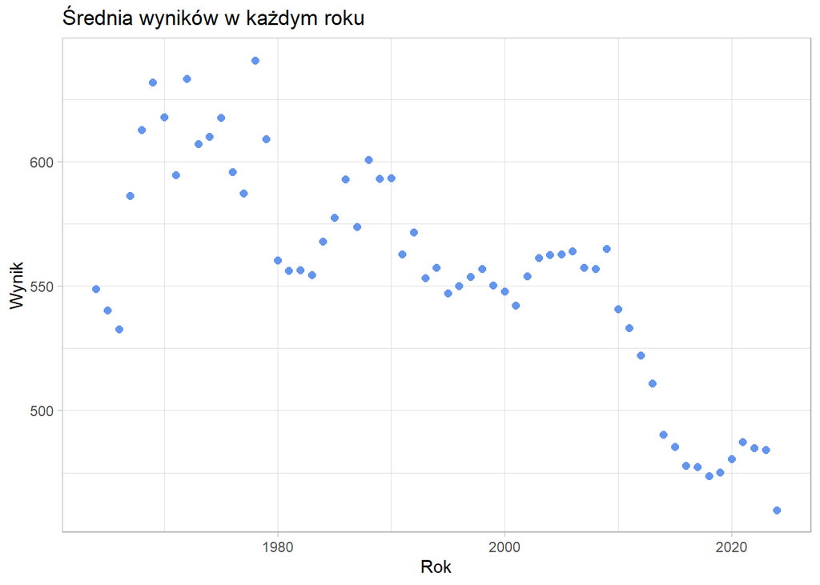

```r
SBDrokGrupowany <- SBDrok %>%
  group_by(Rok) %>%
  summarize('SredniaWynikow' = mean(TotalKg, na.rm = TRUE))
SBDrokGrupowany %>%
  ggplot() +
  theme_light()+
  geom_point(aes(x=Rok,y=SredniaWynikow),size=2,color="cornflowerblue")+
  labs(title="Średnia wyników w każdym roku",
       x="Rok",
       y="Wynik")
```

Jak widać wykres mówi nam, że wyniki spadały na przestrzeni lat. Jaki może być tego powód?

```r
table(SBDrok$Rok)
```

```
##
##   1964   1965   1966   1967   1968   1969   1970   1971   1972   1973   1974
##      5      9     15     17     22     16     25     50     45     44     63
##   1975   1976   1977   1978   1979   1980   1981   1982   1983   1984   1985
##     76     81    158    149    352   1693   2140   2617   2881   2762   2216
##   1986   1987   1988   1989   1990   1991   1992   1993   1994   1995   1996
##   1224   1687   2010   2118   2692   2901   2990   3607   3513   4495   4621
##   1997   1998   1999   2000   2001   2002   2003   2004   2005   2006   2007
##   5046   5545   6351   7315   8300  10253  11183  11259  12142  12339  14743
##   2008   2009   2010   2011   2012   2013   2014   2015   2016   2017   2018
##  16228  15416  19848  22954  27414  35090  50176  65518  80328  89988 102028
##   2019   2020   2021   2022   2023   2024
## 110287  48921  84247 108671 118904    287
```

Myślę, że odpowiedziom na o pytanie może być wzrastająca popularność, jak widać w starszych zawodach nie brało udziału dużo osób ponadto powstawały także nowe kategorie wagowe oraz sport ten stawał sie bardziej przystępny dla kobiet, także osób młodych.

# Który kraj uzyskał najlepsza średnią wyników?

Na początek stworzę ramkę danych, która będzie zawierała ranking krajów, który będzie zawierał średni wynik wszystkich zawodników, którzy pochodzili z danego kraju.

```r
KrajeRanking <- SBDName %>%
  group_by(Country) %>%
  summarise(SredniaTotalKg = mean(TotalKg, na.rm = TRUE))%>%
  arrange(desc(SredniaTotalKg))%>%
  mutate(Miejsce = row_number())
```

Teraz narysuję wykres kolumnowy dziesięciu pierwszych miejsc w rankingu krajów

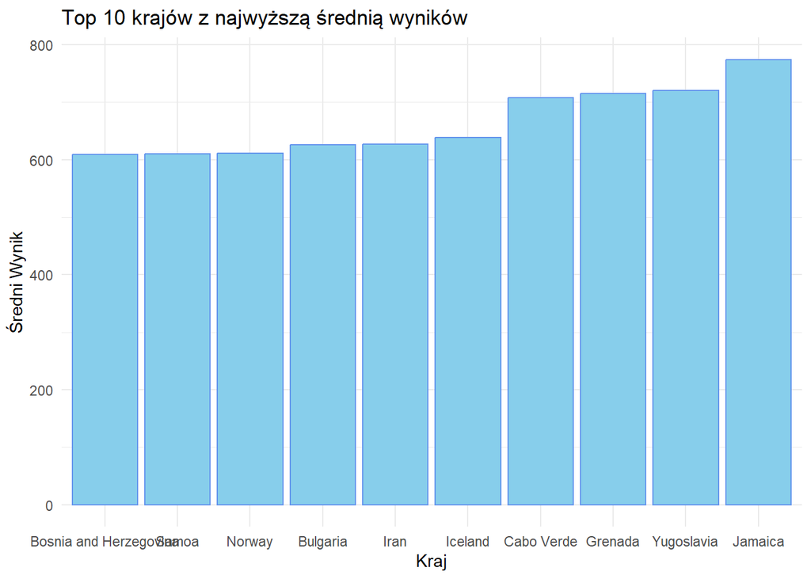

```r
top10Kraje <- KrajeRanking %>%
  head(10)

 top10Kraje %>%
  ggplot( aes(x = reorder(Country, SredniaTotalKg), y = SredniaTotalKg)) +
  geom_bar(stat = "identity",color="cornflowerblue", fill = "skyblue") +
  theme_minimal() +
  labs(title = "Top 10 krajów z najwyższą średnią wyników",
       x = "Kraj",
       y = "Średni Wynik")
```

```r
 miejscePolski <- KrajeRanking %>%
   filter(Country == "Poland") %>%
   pull(Miejsce)
miejscePolski
```

```
## [1] 64
```